# Car Prices

## Background

### Details

Data was collected regarding the prices of a large variety of vehicle with differing make, model, mileage and so forth. This data can serve a large range of purposes, many of which can help those in the market of buying and selling a vehicle. We would like to use this data set to create a model that can help accurately predict the price of a Chevrolet vehicle depending upon the number of miles used, and how that price will change with every additional mile driven. To do this, we must run a Multiple Linear Regression test. This test will first see if there is a difference in price between the Chevrolet vehicles and then give us the needed information to predict price.

In the Separate tabs the data has been displayed.

**Hypothesis**

$$H_0: \beta_j = 0$$
$$H_a: \beta_j \neq 0$$
$$\text{Level of Significance}: \alpha = .05$$

### Data - Car Prices (Chevrolet Only)

```r
chevy <- droplevels(subset(CarPrices, Make == "Chevrolet"))

chevyleather <- droplevels(subset(chevy, Make == "Chevrolet" & Doors == 4 & Cruise == 1 & Leather == 1))


datatable(chevyleather[c( "Make", "Price", "Mileage", "Model","Type")], class = 'cell-border stripe', options = list(pageLength =8, dom = 'tip'), rownames = FALSE, caption = "Data - Car Prices Chevrolet ")
```

| Make | Price | Mileage | Model | Type |
| --- | --- | --- | --- | --- |
| Chevrolet | 11045.10884 | 24568 | AVEO | Hatchback |
| Chevrolet | 12409.94909 | 11981 | AVEO | Sedan |
| Chevrolet | 11343.05401 | 20186 | AVEO | Hatchback |
| Chevrolet | 11247.86253 | 21427 | AVEO | Hatchback |
| Chevrolet | 11013.87137 | 25746 | AVEO | Hatchback |
| Chevrolet | 11115.01364 | 30056 | AVEO | Hatchback |
| Chevrolet | 10805.13009 | 21013 | AVEO | Sedan |
| Chevrolet | 10813.34352 | 266 | AVEO | Hatchback |
| Chevrolet | 10287.97736 | 16521 | AVEO | Hatchback |
| Chevrolet | 9220.829677 | 29992 | AVEO | Hatchback |

[output cut: 75 more lines]

### Data - Car Prices (All Cars)

```r
datatable(CarPrices[c( "Make", "Price", "Mileage", "Model","Type")], class = 'cell-border stripe', options = list(pageLength =8, dom = 'tip'), rownames = FALSE, caption = "Data - Car Prices All")
```

| Make | Price | Mileage | Model | Type |
| --- | --- | --- | --- | --- |
| Buick | 17314.10313 | 8221 | Century | Sedan |
| Buick | 17542.03608 | 9135 | Century | Sedan |
| Buick | 16218.84786 | 13196 | Century | Sedan |
| Buick | 16336.91314 | 16342 | Century | Sedan |
| Buick | 16339.17032 | 19832 | Century | Sedan |
| Buick | 15709.05282 | 22236 | Century | Sedan |
| Buick | 15230.00339 | 22576 | Century | Sedan |
| Buick | 15048.04218 | 22964 | Century | Sedan |
| Buick | 14862.09387 | 24021 | Century | Sedan |
| Buick | 15295.01827 | 27325 | Century | Sedan |

[output cut: 794 more lines]

## Analysis

**Multiple Linear Regression Test**

```r
carlm <- lm(Price ~ Mileage + Model, data = chevyleather)
pander(summary(carlm))
```

|  | Estimate | Std. Error | t value | Pr(>\|t\|) |
| --- | --- | --- | --- | --- |
| **(Intercept)** | 12986 | 627.2 | 20.7 | 1.985e-33 |
| **Mileage** | -0.1019 | 0.02179 | -4.675 | 1.211e-05 |
| **ModelCavalier** | 2163 | 567.7 | 3.81 | 0.0002754 |
| **ModelClassic** | 2773 | 775.3 | 3.577 | 0.0006007 |
| **ModelCobalt** | 3056 | 634.1 | 4.82 | 6.956e-06 |
| **ModelImpala** | 8510 | 567.7 | 14.99 | 1.116e-24 |
| **ModelMalibu** | 6062 | 529.6 | 11.45 | 2.282e-18 |

Fitting linear model: Price ~ Mileage + Model

| Observations | Residual Std. Error | $R^2$ | Adjusted $R^2$ |
| --- | --- | --- | --- |
| 85 | 1414 | 0.8157 | 0.8015 |

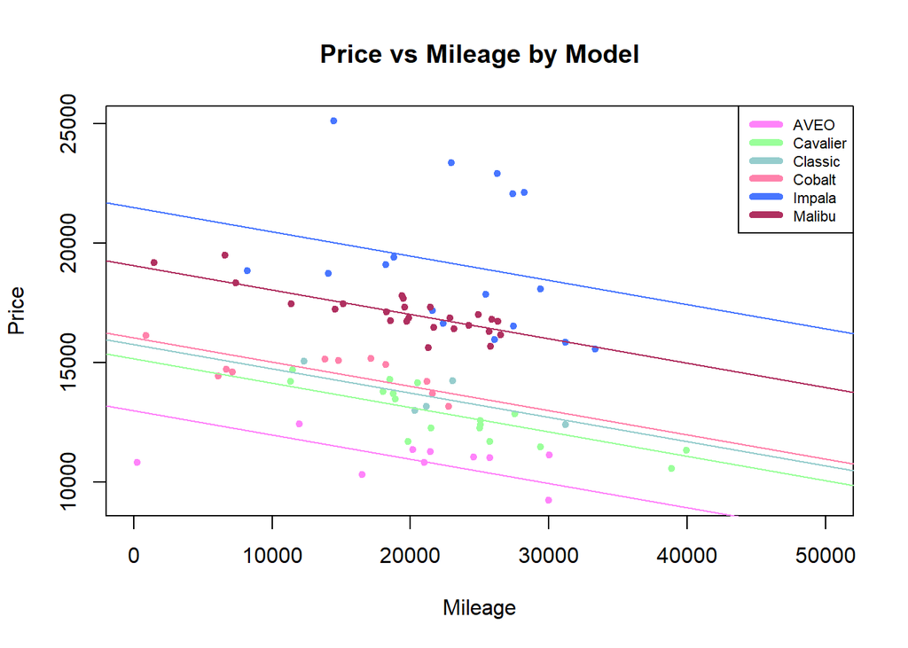

```r
palette(c("orchid1","palegreen1","paleturquoise3","palevioletred1","royalblue1", "maroon"))
plot(Price ~ Mileage, data = chevyleather, pch = 20, col = chevyleather$Model, xlim = c(0,50000), main = "Price vs Mileage by Model")
abline(carlm$coef[1]              , carlm$coef[2], col = palette()[1])
abline(carlm$coef[1]+carlm$coef[3], carlm$coef[2], col = palette()[2])
abline(carlm$coef[1]+carlm$coef[4], carlm$coef[2], col = palette()[3])
abline(carlm$coef[1]+carlm$coef[5], carlm$coef[2], col = palette()[4])
abline(carlm$coef[1]+carlm$coef[6], carlm$coef[2], col = palette()[5])
abline(carlm$coef[1]+carlm$coef[7], carlm$coef[2], col = palette()[6])
legend("topright", carlm$xlevels$Model, lty = 1, lwd = 5, col = palette(), cex = 0.7)
```

This is a scatter plot of the Price vs Mileage of the Chevrolet vehicles. The lines that fit the data for each model roughly follow this equation: $y = -.1019x + \text{Intercept}$ The intercept will be different depending upon the model chosen.

### Assumptions for Testing the Data

#### Assumptions

The assumptions of multiple linear regression are what follows. These assumptions must be true for the data to appropriately fit the test that was run.

- The regression relation between `Y` and `X` is linear.
- The error terms are normally distributed with `E{ϵi}=0.`
- The variance of the error terms is constant over all `X` values.
- The `X` values can be considered fixed and measured without error.
- The error terms are independent.
- All important variables are included in the model.

#### Residual vs Fitted

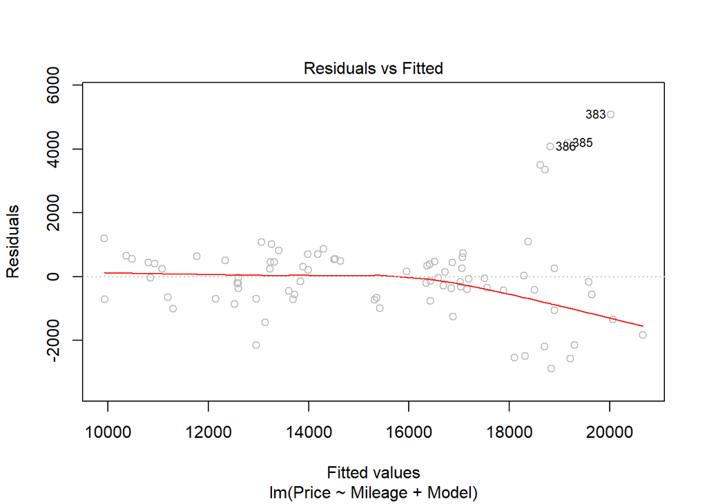

```r
plot(carlm, which = 1, col = "grey")
```

#### Normal Q-Q

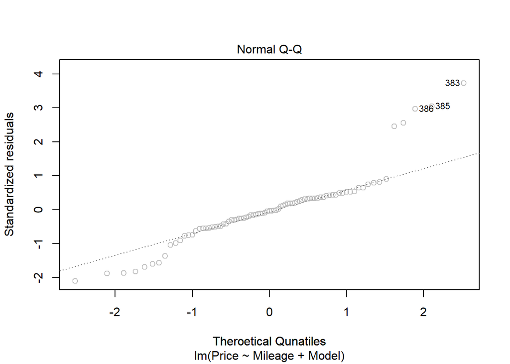

```r
plot(carlm, which = 2, xlab = "Theroetical Qunatiles", col = "grey")
```

#### Residuals

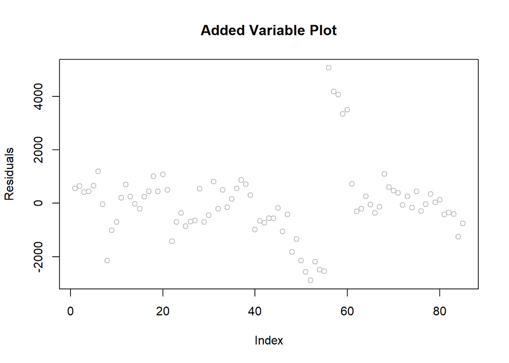

```r
plot(carlm$residuals, ylab = "Residuals", main = "Added Variable Plot", col = "grey")
```

This graph is used to see if the added variable has any information to add to the current multiple regression model. We can tell this through the graph if there is a trend in the added variable plot. As we can see by the above graph there is a trend found meaning the new explanatory variable contains extra information that is not already contained in the current multiple regression.

## Interpretation

The results from the Multiple Linear Regression are this:

1. All the resulting pValues are less than the level of significance. $p < .001$ and $P < \alpha$. With this information we can stat that there is sufficient evidence to reject the null hypotheses, meaning the prices of the vehicles differ, and there is significance in the variable `Mileage`.
2. The model is strong because $R^2 = 0.8157$ which is rather close to 1.
3. With ever mile driven the price of the car is lowered by 10 cents.
4. The resulting equation to predict price is: $y = -.1019x + \text{Intercept}$, where $y = \text{Price}$, $x = \text{Mileage}$, and the Intercept is provided above for the differing model types.